# Project - Concrete Strength Prediction

### Steps

- Data loading and preprocessing
- Exploratory Data Analysis
- Model building and evaluation
- Identify the better parameter using Cross Validation Mean Score
- Hyper Parameters Tuning for the best model identified in above step

```python
#Importing Libraries

import pandas as pd
import numpy as np
import matplotlib.pyplot as plt
import seaborn as sns
%matplotlib inline

sns.set(color_codes=True)
sns.set_style(style='darkgrid') #Update default background style of plots

pd.options.display.float_format = '{:,.2f}'.format #Display all numbers with 2 decimal points

from sklearn.model_selection import train_test_split

from sklearn import metrics

import warnings
warnings.filterwarnings('ignore')

#ML model Libraries
from sklearn.linear_model import LinearRegression
from sklearn.tree import DecisionTreeClassifier
from sklearn.ensemble import RandomForestClassifier
from sklearn.ensemble import AdaBoostClassifier
from sklearn.ensemble import BaggingClassifier
from sklearn.ensemble import GradientBoostingClassifier
```

```python
# Read the dataset
df = pd.read_csv("concrete.csv")
df.head()
```

|  | cement | slag | ash | water | superplastic | coarseagg | fineagg | age | strength |
| --- | --- | --- | --- | --- | --- | --- | --- | --- | --- |
| 0 | 141.30 | 212.00 | 0.00 | 203.50 | 0.00 | 971.80 | 748.50 | 28 | 29.89 |
| 1 | 168.90 | 42.20 | 124.30 | 158.30 | 10.80 | 1,080.80 | 796.20 | 14 | 23.51 |
| 2 | 250.00 | 0.00 | 95.70 | 187.40 | 5.50 | 956.90 | 861.20 | 28 | 29.22 |
| 3 | 266.00 | 114.00 | 0.00 | 228.00 | 0.00 | 932.00 | 670.00 | 28 | 45.85 |
| 4 | 154.80 | 183.40 | 0.00 | 193.30 | 9.10 | 1,047.40 | 696.70 | 28 | 18.29 |

```python
df.shape
```

```
(1030, 9)
```

## Univariate Analysis

```python
# All fields are Numeric & Not NULL
df.info()
```

```
<class 'pandas.core.frame.DataFrame'>
RangeIndex: 1030 entries, 0 to 1029
Data columns (total 9 columns):
 #   Column        Non-Null Count  Dtype
---  ------        --------------  -----
 0   cement        1030 non-null   float64
 1   slag          1030 non-null   float64
 2   ash           1030 non-null   float64
 3   water         1030 non-null   float64
 4   superplastic  1030 non-null   float64
 5   coarseagg     1030 non-null   float64
 6   fineagg       1030 non-null   float64
 7   age           1030 non-null   int64
 8   strength      1030 non-null   float64
dtypes: float64(8), int64(1)
memory usage: 72.5 KB
```

```python
# Total 8 independent and 1 dependent variable
df.columns
```

```
Index(['cement', 'slag', 'ash', 'water', 'superplastic', 'coarseagg',
       'fineagg', 'age', 'strength'],
      dtype='object')
```

```python
# No NULL values in data
df.isnull().any()
```

```
cement          False
slag            False
ash             False
water           False
superplastic    False
coarseagg       False
fineagg         False
age             False
strength        False
dtype: bool
```

### Print the descriptive statistics of each & every column using describe() function

```python
df.describe().transpose()

## Inference -
# For the fields slag, ash & age - there is a variance in mean and median. There may be outliers in these fields.
# For other fields mean and median are almost same, suggests symmetrical distribution of data
```

|  | count | mean | std | min | 25% | 50% | 75% | max |
| --- | --- | --- | --- | --- | --- | --- | --- | --- |
| cement | 1,030.00 | 281.17 | 104.51 | 102.00 | 192.38 | 272.90 | 350.00 | 540.00 |
| slag | 1,030.00 | 73.90 | 86.28 | 0.00 | 0.00 | 22.00 | 142.95 | 359.40 |
| ash | 1,030.00 | 54.19 | 64.00 | 0.00 | 0.00 | 0.00 | 118.30 | 200.10 |
| water | 1,030.00 | 181.57 | 21.35 | 121.80 | 164.90 | 185.00 | 192.00 | 247.00 |
| superplastic | 1,030.00 | 6.20 | 5.97 | 0.00 | 0.00 | 6.40 | 10.20 | 32.20 |
| coarseagg | 1,030.00 | 972.92 | 77.75 | 801.00 | 932.00 | 968.00 | 1,029.40 | 1,145.00 |
| fineagg | 1,030.00 | 773.58 | 80.18 | 594.00 | 730.95 | 779.50 | 824.00 | 992.60 |
| age | 1,030.00 | 45.66 | 63.17 | 1.00 | 7.00 | 28.00 | 56.00 | 365.00 |
| strength | 1,030.00 | 35.82 | 16.71 | 2.33 | 23.71 | 34.45 | 46.14 | 82.60 |

#### Using univariate analysis to check the individual attributes for their basic statistic such as central values, spread, tails, outliers, etc.

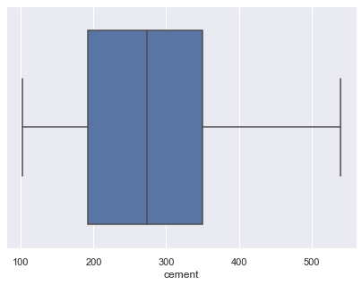

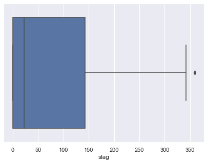

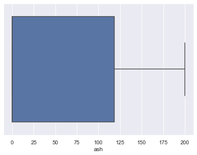

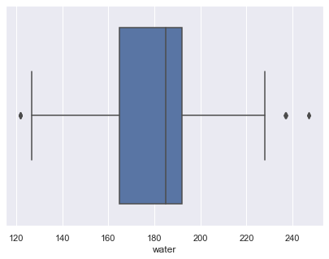

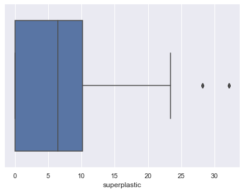

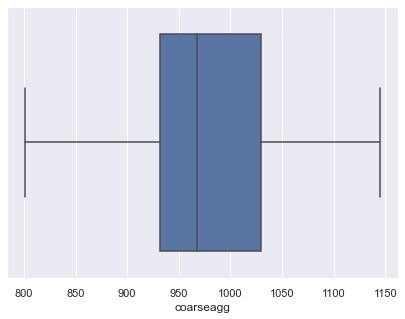

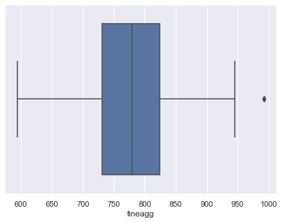

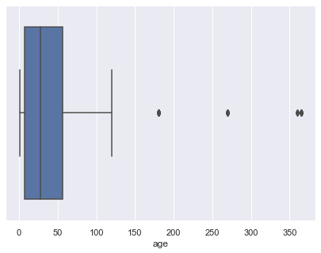

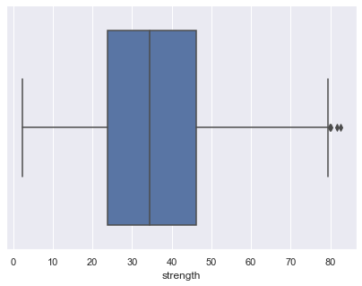

```python
for i in df.columns:
    plt.figure(figsize = (7,5))
    sns.boxplot(df[i])
    plt.show()
```

```
Mean:  35.817961165048544
Median:  34.445
Mode:  33.4
```

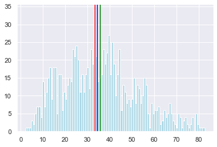

```python
# Analysing the mean, median and mode of Target field "strength"

mean = df['strength'].mean()
median = df['strength'].median()
mode = df['strength'].mode()
print ('Mean: ',mean,'\nMedian: ',median,'\nMode: ',mode[0])
plt.hist(df['strength'],bins=100, color='lightblue')
plt.axvline(mean,color='green',label='Mean')
plt.axvline(median,color='blue',label='Median')
plt.axvline(mode[0],color='red',label='Mode')
```

### Multivariate Analysis

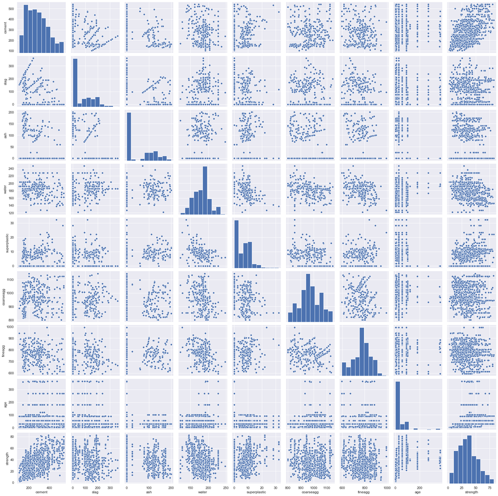

```python
sns.pairplot(df)
```

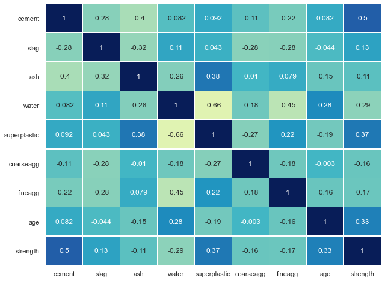

```python
## Correlation betweeen all numeric fields

plt.figure(figsize=(10,8))

sns.heatmap(df.corr(),
            annot=True,
            linewidths=.5,
            center=0,
            cbar=False,
            cmap="YlGnBu")

plt.show()
```

### Inference from Correlation heat map -

- Target field Strength has a relationship with Cement, Superplastic, Age and Water.
- Superplastic and Water have an inverse relationsip.
- Fineagg and water have an inverse relationship.
- Strength and Cement have a positive correlation.

## Getting the Model Ready

#### Splitting into x & y arrays holding dependent and independent variables

```python
# Separate the independent attributes i.e. every column except Strength
# Store the target column (Strength) into Y array

x = df.loc[:, df.columns != 'strength']  # independent variables
y = df.loc[:, df.columns == 'strength']  # Target variable
```

### Split into Train and Test data

```python
from sklearn.model_selection import train_test_split

x_train,x_test,y_train,y_test = train_test_split(x,y,test_size=0.3,random_state=5)
```

### Scaling the Train data

Applying scaling to Train and Test data separately to prevent data leakage.

**(After applying scaling didnt find significant performance gain, so commented this piece)**

```python
#Here we are going to use StandardScaler to scale our data.
#from sklearn.preprocessing import StandardScaler

#scaler = StandardScaler()
#cols_to_scale = ['cement', 'slag', 'ash', 'water', 'superplastic', 'coarseagg','fineagg', 'age']

#x_train[cols_to_scale] = scaler.fit_transform(x_train[cols_to_scale].to_numpy())
```

### Scaling the Test data

```python
#Here we are going to use StandardScaler to scale our data.
#from sklearn.preprocessing import StandardScaler

#scaler = StandardScaler()
#cols_to_scale = ['cement', 'slag', 'ash', 'water', 'superplastic', 'coarseagg','fineagg', 'age']

#x_test[cols_to_scale] = scaler.fit_transform(x_test[cols_to_scale].to_numpy())
```

```python
x_train.head(3)
```

|  | cement | slag | ash | water | superplastic | coarseagg | fineagg | age |
| --- | --- | --- | --- | --- | --- | --- | --- | --- |
| 370 | 266.00 | 114.00 | 0.00 | 228.00 | 0.00 | 932.00 | 670.00 | 180 |
| 841 | 313.30 | 262.20 | 0.00 | 175.50 | 8.60 | 1,046.90 | 611.80 | 3 |
| 297 | 475.00 | 0.00 | 0.00 | 228.00 | 0.00 | 932.00 | 594.00 | 270 |

```python
#x_train.describe().transpose()
```

```python
x_test.head(3)
```

|  | cement | slag | ash | water | superplastic | coarseagg | fineagg | age |
| --- | --- | --- | --- | --- | --- | --- | --- | --- |
| 34 | 331.00 | 0.00 | 0.00 | 192.00 | 0.00 | 1,025.00 | 821.00 | 90 |
| 33 | 313.00 | 145.00 | 0.00 | 127.00 | 8.00 | 1,000.00 | 822.00 | 28 |
| 478 | 190.70 | 0.00 | 125.40 | 162.10 | 7.80 | 1,090.00 | 804.00 | 14 |

### Applying Linear Regression (Quadratic - 2 degrees)

```python
from sklearn.linear_model import LinearRegression
from sklearn.preprocessing import PolynomialFeatures
from sklearn.metrics import mean_absolute_error, mean_squared_error, r2_score

polynomial_features= PolynomialFeatures(degree=2)
x_poly_train = polynomial_features.fit_transform(x_train)
x_poly_test = polynomial_features.fit_transform(x_test)

linearregression = LinearRegression()
linearregression.fit(x_poly_train, y_train)

print("Intercept of the linear equation:", linearregression.intercept_)
print("\nCOefficients of the equation are:", linearregression.coef_)


pred = linearregression.predict(x_poly_test)
```

```
Intercept of the linear equation: [-3637.09156879]

COefficients of the equation are: [[ 1.65528279e-10  2.04276493e+00  1.33626301e+00  1.15792339e+00
   1.21902606e+01  2.28284793e+01  1.90663698e+00  3.06270880e+00
   4.15050117e-01 -2.74959742e-04 -2.73714714e-04 -1.07386530e-04
  -3.79011050e-03 -7.08254224e-03 -4.22428583e-04 -7.88694262e-04
   1.38140448e-04 -1.24132682e-04  3.00017255e-04 -2.60515953e-03
  -7.18057208e-03 -3.23093819e-04 -4.43359446e-04  3.62459527e-04
   2.15958288e-04 -3.47966413e-03 -1.35719266e-02 -1.87603699e-04
  -3.21733772e-04  6.06092975e-04 -8.12932576e-03 -2.35235589e-02
  -4.07997051e-03 -4.96162353e-03 -6.52752537e-04 -4.37667934e-02
  -6.79827176e-03 -9.85095760e-03  1.37989235e-03 -2.02266246e-04
  -7.35688454e-04 -1.53101245e-04 -7.22680903e-04  1.34723709e-04
  -6.57412969e-04]]
```

```python
# Regression Metrics
RMSE_LR = mean_squared_error(y_test, pred)**0.5
Score_LR = linearregression.score(x_poly_test, y_test)

print("Mean Absolute Error : ",mean_absolute_error(y_test, pred))
print ("Root Mean Squared Error : ",RMSE_LR)
print ("R2 Squared : ",r2_score(y_test, pred))
print ("Training Score : ",linearregression.score(x_poly_train, y_train))
print ("Testing Score : ",Score_LR)
```

```
Mean Absolute Error :  5.874239363907187
Root Mean Squared Error :  7.673496654497038
R2 Squared :  0.7792816248485032
Training Score :  0.8167294808971457
Testing Score :  0.7792816248485032
```

```python
#Store the score for each model in a dataframe for final comparison
resultsDf = pd.DataFrame({'Method':['Linear Regression'],'RMSE':RMSE_LR,'Score':Score_LR})
resultsDf = resultsDf[['Method','RMSE','Score']]
resultsDf
```

|  | Method | RMSE | Score |
| --- | --- | --- | --- |
| 0 | Linear Regression | 7.67 | 0.78 |

### Decision Tree

```python
from sklearn.tree import DecisionTreeRegressor

dt = DecisionTreeRegressor(max_depth=5)

dt.fit(x_train, y_train)

Score_DT = dt.score(x_test, y_test)
pred_dt = dt.predict(x_test)
RMSE_DT = mean_squared_error(y_test, pred_dt)**0.5

print ("Root Mean Squared Error : ",RMSE_DT)
print("Training Score : ",dt.score(x_train, y_train))  # performance on train data
print("Testing Score : ",Score_DT)  # performance on test data
```

```
Root Mean Squared Error :  7.802761786682415
Training Score :  0.8109654602581166
Testing Score :  0.7717826958390969
```

```python
## Feature Importance of Decision Tree
pd.Series(dt.feature_importances_, x_train.columns ).sort_values(ascending= False)
```

```
cement         0.39
age            0.37
water          0.11
slag           0.09
superplastic   0.02
fineagg        0.01
ash            0.00
coarseagg      0.00
dtype: float64
```

```python
#Store the score for each model in a dataframe for final comparison
tempResultsDf = pd.DataFrame({'Method':['Decision Tree'],'RMSE':RMSE_DT,'Score':Score_DT})
resultsDf = pd.concat([resultsDf, tempResultsDf])
resultsDf
```

|  | Method | RMSE | Score |
| --- | --- | --- | --- |
| 0 | Linear Regression | 7.67 | 0.78 |
| 0 | Decision Tree | 7.80 | 0.77 |

### Random Forest

```python
from sklearn.ensemble import RandomForestRegressor

rf = RandomForestRegressor(max_depth=6)

rf.fit(x_train, y_train)

Score_RF = rf.score(x_test, y_test)
pred_rf = rf.predict(x_test)
RMSE_RF = mean_squared_error(y_test, pred_rf)**0.5


print ("Root Mean Squared Error : ",RMSE_RF)
print("Training Score :",rf.score(x_train, y_train))  # performance on train data
print("Testing Score : ",Score_RF)  # performance on test data
```

```
Root Mean Squared Error :  6.060608798561026
Training Score : 0.9234241969465241
Testing Score :  0.8623157135719854
```

```python
## Feature Importance of RandomForest
pd.Series(rf.feature_importances_, x_train.columns).sort_values(ascending= False)
```

```
age            0.37
cement         0.32
water          0.10
superplastic   0.08
slag           0.07
fineagg        0.03
coarseagg      0.01
ash            0.01
dtype: float64
```

```python
#Store the score for each model in a dataframe for final comparison
tempResultsDf = pd.DataFrame({'Method':['Random Forest'],'RMSE':RMSE_RF, 'Score':Score_RF})
resultsDf = pd.concat([resultsDf, tempResultsDf])
resultsDf
```

|  | Method | RMSE | Score |
| --- | --- | --- | --- |
| 0 | Linear Regression | 7.67 | 0.78 |
| 0 | Decision Tree | 7.80 | 0.77 |
| 0 | Random Forest | 6.06 | 0.86 |

### Apply Adaboost Ensemble Algorithm

```python
from sklearn.ensemble import AdaBoostRegressor
abr = AdaBoostRegressor(n_estimators=80)
abr.fit(x_train, y_train)

Score_AB = abr.score(x_test, y_test)
pred_ab = abr.predict(x_test)
RMSE_AB = mean_squared_error(y_test, pred_ab)**0.5

print ("Root Mean Squared Error : ",RMSE_AB)
print("Training Score :",abr.score(x_train, y_train))  # performance on train data
print("Testing Score : ",Score_AB)  # performance on test data
```

```
Root Mean Squared Error :  8.058193556324268
Training Score : 0.8281643467591902
Testing Score :  0.756596250591387
```

```python
#Store the score for each model in a dataframe for final comparison
tempResultsDf = pd.DataFrame({'Method':['Adaboost'],'RMSE':RMSE_AB,'Score':Score_AB})
resultsDf = pd.concat([resultsDf, tempResultsDf])
resultsDf
```

|  | Method | RMSE | Score |
| --- | --- | --- | --- |
| 0 | Linear Regression | 7.67 | 0.78 |
| 0 | Decision Tree | 7.80 | 0.77 |
| 0 | Random Forest | 6.06 | 0.86 |
| 0 | Adaboost | 8.06 | 0.76 |

### Apply Bagging Regression Algorithm

```python
from sklearn.ensemble import BaggingRegressor

bgr = BaggingRegressor(n_estimators=80)
bgr.fit(x_train, y_train)

Score_BG = bgr.score(x_test, y_test)
pred_bgr = bgr.predict(x_test)
RMSE_BG = mean_squared_error(y_test, pred_bgr)**0.5


print ("Root Mean Squared Error : ",RMSE_BG)
print("Training Score :",bgr.score(x_train, y_train))  # performance on train data
print("Testing Score : ",Score_BG)  # performance on test data
```

```
Root Mean Squared Error :  4.961634037769607
Training Score : 0.9828570294353521
Testing Score :  0.9077213291128452
```

```python
#Store the score for each model in a dataframe for final comparison
tempResultsDf = pd.DataFrame({'Method':['Bagging'],'RMSE':RMSE_BG, 'Score':Score_BG})
resultsDf = pd.concat([resultsDf, tempResultsDf])
resultsDf
```

|  | Method | RMSE | Score |
| --- | --- | --- | --- |
| 0 | Linear Regression | 7.67 | 0.78 |
| 0 | Decision Tree | 7.80 | 0.77 |
| 0 | Random Forest | 6.06 | 0.86 |
| 0 | Adaboost | 8.06 | 0.76 |
| 0 | Bagging | 4.96 | 0.91 |

### Apply GradientBoost Regression Algorithm

```python
from sklearn.ensemble import GradientBoostingRegressor
gbr = GradientBoostingRegressor(max_depth=5)
gbr.fit(x_train, y_train)

Score_GB = gbr.score(x_test, y_test)
pred_gbr = gbr.predict(x_test)
RMSE_GB = mean_squared_error(y_test, pred_gbr)**0.5


print ("Root Mean Squared Error : ",RMSE_GB)
print("Training Score :",gbr.score(x_train, y_train))  # performance on train data
print("Testing Score : ",Score_GB)  # performance on test data
```

```
Root Mean Squared Error :  4.512408132117798
Training Score : 0.9874193590842119
Testing Score :  0.923674682318513
```

```python
#Store the score for each model in a dataframe for final comparison
tempResultsDf = pd.DataFrame({'Method':['Gradient Boost'],'RMSE':RMSE_GB,'Score':Score_GB})
resultsDf = pd.concat([resultsDf, tempResultsDf])
resultsDf
```

|  | Method | RMSE | Score |
| --- | --- | --- | --- |
| 0 | Linear Regression | 7.67 | 0.78 |
| 0 | Decision Tree | 7.80 | 0.77 |
| 0 | Random Forest | 6.06 | 0.86 |
| 0 | Adaboost | 8.06 | 0.76 |
| 0 | Bagging | 4.96 | 0.91 |
| 0 | Gradient Boost | 4.51 | 0.92 |

### Apply XGBoost

```python
from xgboost import XGBRegressor
xgb = XGBRegressor(max_depth=5)
xgb.fit(x_train, y_train)

Score_XG = xgb.score(x_test, y_test)
pred_xgb = xgb.predict(x_test)
RMSE_XG = mean_squared_error(y_test, pred_xgb)**0.5


print ("Root Mean Squared Error : ",RMSE_XG)
print("Training Score :",xgb.score(x_train, y_train))  # performance on train data
print("Testing Score : ",Score_XG)  # performance on test data
```

```
Root Mean Squared Error :  4.294046241587306
Training Score : 0.9939067763135377
Testing Score :  0.9308829317963407
```

```python
#Store the score for each model in a dataframe for final comparison
tempResultsDf = pd.DataFrame({'Method':['XG Boost'],'RMSE':RMSE_XG,'Score':Score_XG})
resultsDf = pd.concat([resultsDf, tempResultsDf])
resultsDf
```

|  | Method | RMSE | Score |
| --- | --- | --- | --- |
| 0 | Linear Regression | 7.67 | 0.78 |
| 0 | Decision Tree | 7.80 | 0.77 |
| 0 | Random Forest | 6.06 | 0.86 |
| 0 | Adaboost | 8.06 | 0.76 |
| 0 | Bagging | 4.96 | 0.91 |
| 0 | Gradient Boost | 4.51 | 0.92 |
| 0 | XG Boost | 4.29 | 0.93 |

## Comparison of Root Mean Square Error and Score of the Models

**Looking at the table above following Models are giving better performance and will be further tuned**

- XG Boost
- Gradient Boost
- Bagging
- Random Forest

## Applying Cross Validation to identify the best Model

```python
# Applying Cross Validation and computing Cross Validation score for Random Forest, Bagging, Gradient Boost & XG Boost models

from sklearn.model_selection import cross_val_score

Score_RF_CV = cross_val_score(rf, x, y, cv = 10)
Score_BG_CV = cross_val_score(bgr, x, y, cv = 10)
Score_GB_CV = cross_val_score(gbr, x, y, cv = 10)
Score_XG_CV = cross_val_score(xgb, x, y, cv = 10)


print(f'Cross validation score of Random Forest = {Score_RF_CV}')
print(f'Cross validation score of Bagging = {Score_BG_CV}')
print(f'Cross validation score of Gradient Boost = {Score_GB_CV}')
print(f'Cross validation score of XG Boost = {Score_XG_CV}')
```

```
Cross validation score of Random Forest = [0.83245321 0.83268632 0.89588484 0.86523853 0.84986108 0.89581474
 0.89140179 0.8619893  0.86404746 0.86459282]
Cross validation score of Bagging = [0.87580335 0.89652245 0.95316997 0.92368766 0.88231543 0.93912788
 0.93790384 0.92272546 0.92018047 0.93081792]
Cross validation score of Gradient Boost = [0.88558839 0.91108077 0.96340339 0.92539145 0.90007979 0.94506846
 0.95091418 0.93342974 0.9453198  0.93551392]
Cross validation score of XG Boost = [0.89576523 0.91573664 0.96721502 0.93227399 0.91215654 0.94070372
 0.95617473 0.95206114 0.94105739 0.94823879]
```

### Identify the Mean Score and 95% confidence interval of the score estimate -

```python
#Identify the Mean Score and 95% Confidence interval of all Models
print("Accuracy of Random Forest: %0.2f (+/- %0.2f)" % (Score_RF_CV.mean(), Score_RF_CV.std() * 2))
print("Accuracy of Bagging: %0.2f (+/- %0.2f)" % (Score_BG_CV.mean(), Score_BG_CV.std() * 2))
print("Accuracy of Gradient Boost: %0.2f (+/- %0.2f)" % (Score_GB_CV.mean(), Score_GB_CV.std() * 2))
print("Accuracy of XG Boost: %0.2f (+/- %0.2f)" % (Score_XG_CV.mean(), Score_XG_CV.std() * 2))
```

```
Accuracy of Random Forest: 0.87 (+/- 0.04)
Accuracy of Bagging: 0.92 (+/- 0.05)
Accuracy of Gradient Boost: 0.93 (+/- 0.05)
Accuracy of XG Boost: 0.94 (+/- 0.04)
```

## Inference from Cross Validation

### Model XG Boost is giving the best Performance with Accuracy of 94% (Confidence Interval +/- 4%)

## Hyper Parameter Tuning

Model XG Boost has given best performance to predict the strength of Concrete on the given dataset.

**So, we will be hyper tuning the parameters of XG Boost model**

**Steps:**

- Split the data into training and testing set (70:30) (This is already done before by splitting into train & test datasets)
- Use the training data to perform cross validation hyper parameter tuning using Random Search
- Check the best performing model against the test set

```python
x_train.shape, x_test.shape, y_train.shape, y_test.shape
```

```
((721, 8), (309, 8), (721, 1), (309, 1))
```

```python
from sklearn.model_selection import RandomizedSearchCV

# specify parameters and distributions to sample from
param_grid = {"learning_rate": [0.05,0.1,0.15,0.2],
              "max_depth": [4,5,6,7],
              'n_estimators': list(range(100, 400, 50)),
              'subsample': [0.5,0.6,0.7,0.8]
             }

xg = XGBRegressor()

randomCV_xg = RandomizedSearchCV(xg, param_distributions=param_grid, cv=10)
#GridCV_XG = GridSearchCV(xg, param_grid, cv=10)
```

```python
randomCV_xg.fit(x_train, y_train)
```

```
RandomizedSearchCV(cv=10,
                   estimator=XGBRegressor(base_score=None, booster=None,
                                          colsample_bylevel=None,
                                          colsample_bynode=None,
                                          colsample_bytree=None, gamma=None,
                                          gpu_id=None, importance_type='gain',
                                          interaction_constraints=None,
                                          learning_rate=None,
                                          max_delta_step=None, max_depth=None,
                                          min_child_weight=None, missing=nan,
                                          monotone_constraints=None,
                                          n_estimators=100, n_jobs=None,
                                          num_parallel_tree=None,
                                          random_state=None, reg_alpha=None,
                                          reg_lambda=None,
                                          scale_pos_weight=None, subsample=None,
                                          tree_method=None,
                                          validate_parameters=None,
                                          verbosity=None),
                   param_distributions={'learning_rate': [0.05, 0.1, 0.15, 0.2],
                                        'max_depth': [4, 5, 6, 7],
                                        'n_estimators': [100, 150, 200, 250,
                                                         300, 350],
                                        'subsample': [0.5, 0.6, 0.7, 0.8]})
```

```python
print("Tuned XG Boost Regression Parameters: {}".format(randomCV_xg.best_params_))
```

```
Tuned XG Boost Regression Parameters: {'subsample': 0.5, 'n_estimators': 350, 'max_depth': 6, 'learning_rate': 0.05}
```

```python
# Using Grid Sreach verifying Hyper Parameters computed by Random Search are correct
from sklearn.model_selection import GridSearchCV

# specify parameters and distributions to sample from
param_grid = {"learning_rate": [0.05,0.1,0.15],
              "max_depth": [4,5,6,7],
              'n_estimators': list(range(200, 400, 50)),
              'subsample': [0.5,0.6]
             }

xg = XGBRegressor()

#randomCV_xg = RandomizedSearchCV(xg, param_distributions=param_grid, cv=10)
GridCV_XG = GridSearchCV(xg, param_grid, cv=10)
```

```python
GridCV_XG.fit(x_train, y_train)
```

```
GridSearchCV(cv=10,
             estimator=XGBRegressor(base_score=None, booster=None,
                                    colsample_bylevel=None,
                                    colsample_bynode=None,
                                    colsample_bytree=None, gamma=None,
                                    gpu_id=None, importance_type='gain',
                                    interaction_constraints=None,
                                    learning_rate=None, max_delta_step=None,
                                    max_depth=None, min_child_weight=None,
                                    missing=nan, monotone_constraints=None,
                                    n_estimators=100, n_jobs=None,
                                    num_parallel_tree=None, random_state=None,
                                    reg_alpha=None, reg_lambda=None,
                                    scale_pos_weight=None, subsample=None,
                                    tree_method=None, validate_parameters=None,
                                    verbosity=None),
             param_grid={'learning_rate': [0.05, 0.1, 0.15],
                         'max_depth': [4, 5, 6, 7],
                         'n_estimators': [200, 250, 300, 350],
                         'subsample': [0.5, 0.6]})
```

```python
GridCV_XG.cv_results_['mean_test_score'].mean()
```

```
0.9271699444464824
```

```python
mean = GridCV_XG.best_score_
std = GridCV_XG.cv_results_['mean_test_score'].std()


print(f"Mean validation score: {mean}")
print(f"Validation standard deviation: {std}")
print(f"95% confidence interval: {str(round(mean-(1.96*std),3)) + ' <-> ' + str(round(mean+(1.96*std),3))}")
print(f"Best parameters: {GridCV_XG.best_params_}")
print(f"Test score: {GridCV_XG.score(x_test, y_test)}")
```

```
Mean validation score: 0.9325968978102696
Validation standard deviation: 0.0030068258466225406
95% confidence interval: 0.927 <-> 0.938
Best parameters: {'learning_rate': 0.05, 'max_depth': 6, 'n_estimators': 350, 'subsample': 0.5}
Test score: 0.938038224525479
```

# Conclusion

**In order to predict the strength of concrete -**

- The best model is XG boosting
- Using the above model, we can predict the strength accurately between 92.7% to 93.8% with 95% confidence.